# multi_reg_bodyfat_script

Owen

2/12/2017

## Introduction and preliminaries

I’m going to do a walkthrough of doing multiple regression in R, using a dataset you already looked at, the dataset about what easily measured things about people are good predictors of their amount of body fat, which itself is not so easy to measure.

Lets do the usual preliminaries:

```r
rm(list=ls())
library(tidyverse)
library(GGally)
library(ggfortify)
```

And load the data, here from github:

```r
dd <- read_delim("https://raw.githubusercontent.com/opetchey/BIO144/master/3_datasets/bodyfat.txt",
                      delim="\t", escape_double = FALSE, trim_ws = TRUE)
```

The variable containing the amount of body fat is `bodyfat`. When we previously looked at the dataset we found to variables that looked liked good candidates for indicating body fat, because they appeared strongly correlated with body fat: `abdomen` and `weight`.

Lets reduce the dataset to these variables – it will make things a bit simpler. Which function of the `dplyr` package do we use to select only a few columns?

```r
dd <- select(dd, bodyfat, weight, abdomen)
```

Have a look at the distribution of the variables:

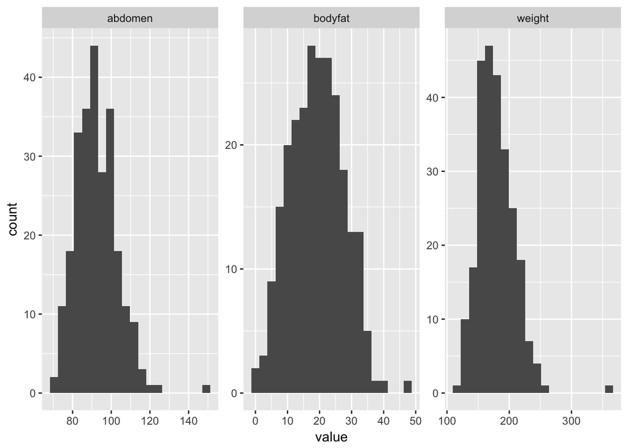

```r
ggplot(data=gather(dd, key=variable, value=value)) +
  geom_histogram(mapping=aes(x=value), bins=20) +
  facet_wrap(~variable, scales="free")
```

There’s some rather large values, e.g. a weight over 300. Lets not exclude these at the moment, but keep them in mind for later.

And the correlations among variables…

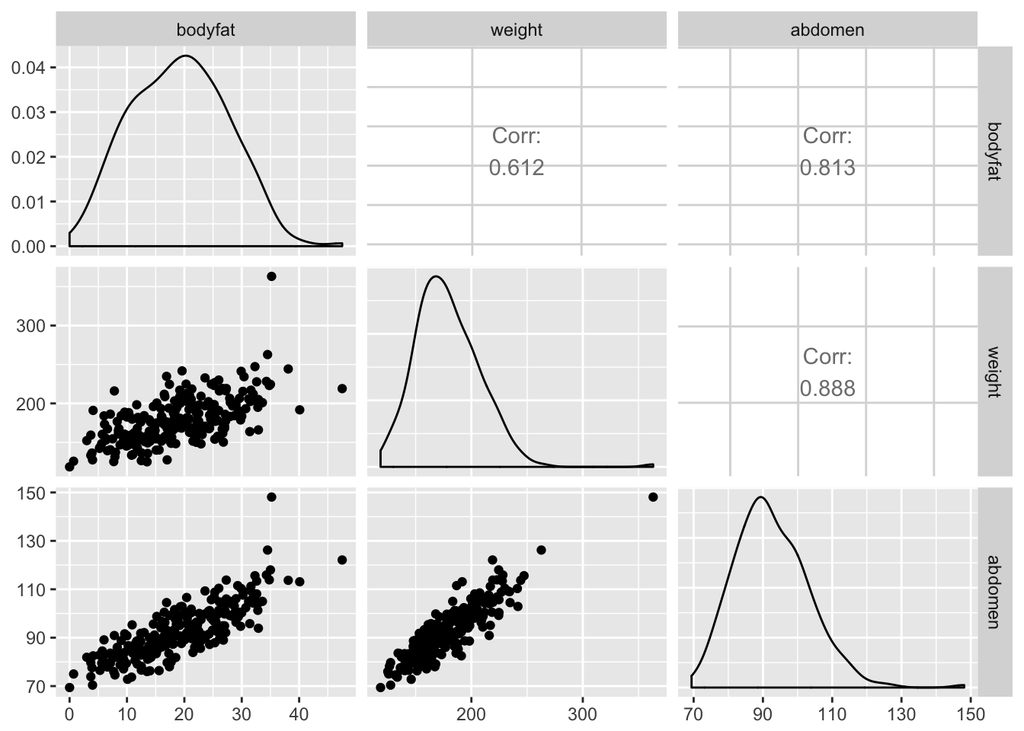

```r
ggpairs(dd)
```

All variables are strongly correlated, even the two predictor variables. This gives the possibility that only one of them will be useful for predicting body fat, and in general, correlated explanatory variables should be a bit of an alarm bell.

Its also worth noting that in this example, we can see the correlations of the response with the explanatory variables, i.e. this is a relatively easy problem. Late in the course you’ll see a multiple regression example in which things are not so obvious at the outset.

## Degrees of freedom

Before we move on, lets figure out how many degrees of freedom for error we should have. First, we see there are 252 data points in total. So that’s our starting point.

Here’s how I was taught how to figure out degrees of freedom: take one away for the total, and the one for each continuous explanatory variable. Both our explanatory variables are continuous, so that three we take away. So we should get 249 degrees of freedom for error.

Here’s how I now think about degrees of freedom: we have the total number of data points, just as before! Now think about the model we’re fitting: how many parameters does it have. Here’s the model we’re fitting (without the error term, sorry Steffi!)

$$y = a + bx_1 + cx_2$$

$y$ is the response variable, and $x_1$ and $x_2$ are the explanatory variables. $a$, $b$, and $c$ are the parameters (also known as coefficients). $a$ is the intercept, $b$ is the slope for $x_1$ and $c$ is the slope for $x_2$.

So to fit the model to the data, we estimate three parameters. So the degrees of freedom is 252 - 3 which is… 249.

I find this method a bit simpler.

Before we tried to guess the slopes, and the r-squared. Here’s it a bit harder to guess slopes, because they depend on each other and so we can’t just get them from the bivariate plots. Still, all the variables are positively correlated, so we might expect the slopes to both be positive.

We expect the r-squared to be quite high though, as the bivariate relationships look quite strong.

## Fitting the model, diagnostics, and the summary table

So, lets fit the model. In R, we put the multiple explanatory variables in the `lm` separated with a plus `+`.

```r
m1 <- lm(bodyfat ~ weight + abdomen, data=dd)
```

The order of weight and abdomen here does not matter. No news is good news.

And the diagnostic plots.

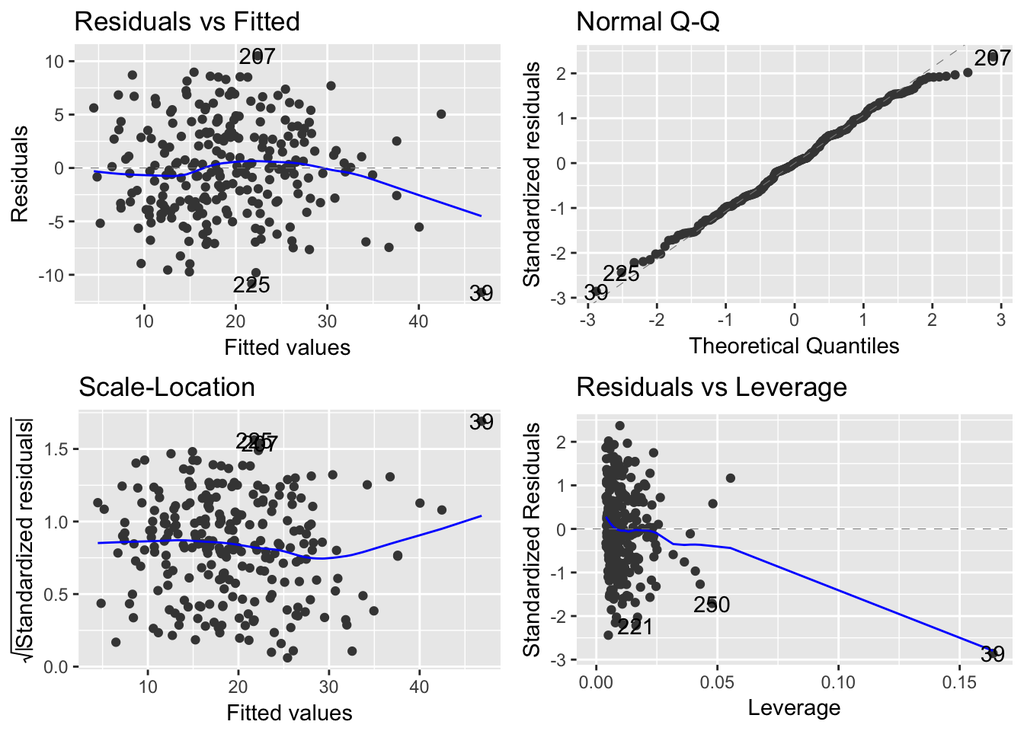

```r
autoplot(m1)
```

Little trend in the residuals, qq plot looks fine. Row 39 is a bit of a problem, its that large weight. Leave it in for now.

How about the summary table:

```r
summary(m1)
```

```
##
## Call:
## lm(formula = bodyfat ~ weight + abdomen, data = dd)
##
## Residuals:
##      Min       1Q   Median       3Q      Max
## -11.6459  -3.2071  -0.0299   3.1664  10.5064
##
## Coefficients:
##              Estimate Std. Error t value Pr(>|t|)
## (Intercept) -45.95237    2.60501 -17.640  < 2e-16 ***
## weight       -0.14800    0.02081  -7.112 1.21e-11 ***
## abdomen       0.98950    0.05672  17.447  < 2e-16 ***
## ---
## Signif. codes:  0 '***' 0.001 '**' 0.01 '*' 0.05 '.' 0.1 ' ' 1
##
## Residual standard error: 4.456 on 249 degrees of freedom
## Multiple R-squared:  0.7188, Adjusted R-squared:  0.7165
## F-statistic: 318.2 on 2 and 249 DF,  p-value: < 2.2e-16
```

So what? Well, first of all, we now know that abdomen and weight are very good explanatory variables, and have the potential to be good predictors of bodyfat, in case we didn’t have the ability to directly measure body fat. This is as expected, we guessed this already, so what have we acheived?

1. We confirmed our guess.
2. We now have a quantitative model we can use to predict bodyfat from the other two. We will do this in a moment.
3. We have found something unexpected: weight is negative related with bodyfat. I.e. heavier people have lower bodyfat, for a given abdomen measurement. Perhaps abdomen is about about how much fat people have, and after that, weight is about how much muscle? Its difficult to tell from this dataset… we’d have to look into the explanation for this.

## Focusing on estimates

If we want to report effect sizes and confidence intervals, as we suggest is often a good idea, we get them like this:

```r
coef(m1)
```

```
## (Intercept)      weight     abdomen
## -45.9523732  -0.1480031   0.9895044
```

```r
confint(m1)
```

```
##                   2.5 %      97.5 %
## (Intercept) -51.0830418 -40.8217046
## weight       -0.1889883  -0.1070178
## abdomen       0.8777997   1.1012092
```

We have the three estimates we previously saw in the summary table. And now we have the 95% confidence intervals (how do we know its 95%? Look in the help file `?confint`).

We see that none of the confidence intervals contain zero, so they are statistically important.

## Visualising the results

How can we show the results? We can’t just show the raw bivariate relationships, as these don’t for example show the negative relationship between bodyfat and weight, for example. One approach is to use the model to make some data that we then plot. How do we use the model to make some data? Well, R has a really nice funciton called `predict`, you may have already come across this, but I’ll go through it step by step.

The simplest way to use predict is to just give it the model. Then it uses the real values of the explanatory variable to make the prediction, i.e. to give values of bodyfat:

```r
predict(m1)
```

```
##         1         2         3         4         5         6         7
## 15.523933 10.534966 18.232596 12.197246 25.728507 16.339203 17.007126
##         8         9        10        11        12        13        14
## 15.570232  7.413159 12.376114  9.204629 12.024920 17.971682 24.401551
##        15        16        17        18        19        20        21
## 21.648281 21.786141 20.464256 19.554670 15.511663 22.153176 22.448555
##        22        23        24        25        26        27        28
## 22.136052  8.888337 11.192527  7.161353  9.341644  8.402256 19.912218
##        29        30        31        32        33        34        35
##  7.450597 12.879756 14.880114 13.943262  7.452914 21.154155 31.840584
##        36        37        38        39        40        41        42
## 37.580993 23.955006 22.691064 46.845924 30.968436 40.035284 26.912313
##        43        44        45        46        47        48        49
## 31.963857 25.876292 10.712581 10.382736  7.215696 10.734776 16.480882
##        50        51        52        53        54        55        56
##  4.838350 16.416178 10.520597 14.873571 10.204713 10.667755 23.693465
##        57        58        59        60        61        62        63
## 25.937615 27.368374 28.271825 24.712364 25.779032 21.298151 26.771291
##        64        65        66        67        68        69        70
## 26.356675 28.025717 26.136361 14.644586 16.835238  8.647300 14.560223
##        71        72        73        74        75        76        77
## 19.796771 14.259146 12.286053 10.749582 15.308909 13.047637  7.970080
##        78        79        80        81        82        83        84
## 21.743005 24.580857 26.267241 24.606651 19.876063 22.663579 22.680076
##        85        86        87        88        89        90        91
## 27.935656 18.089664 17.875486 20.313091 12.985468 13.591223 22.447710
##        92        93        94        95        96        97        98
## 19.665891 11.817940 22.033721 14.646058 18.979781 16.750656 15.787165
##        99       100       101       102       103       104       105
## 18.159440 17.904442 18.671942 19.366504 16.743895 19.425699 25.416223
##       106       107       108       109       110       111       112
## 15.936858 26.131071 24.499656 13.104077 20.440371 18.425207 30.824033
##       113       114       115       116       117       118       119
## 21.669004 18.582726 19.540301 16.354228 16.869484 16.610479 17.209253
##       120       121       122       123       124       125       126
## 12.878692 21.643836 23.700446 12.755857 16.821496 13.436458 18.287565
##       127       128       129       130       131       132       133
## 18.910443  8.695508 18.112704 15.677008 17.782452 18.054354 23.643568
##       134       135       136       137       138       139       140
## 19.272844 15.430900 26.557957 14.564449 23.825191 16.717255 28.041150
```

[output cut: 17 more lines]

```
## 16.019531 17.941661  6.475462 17.534653 15.929878 16.647699 26.390922
##       204       205       206       207       208       209       210
## 14.979910 33.747501 18.441266 22.393586 25.423830 13.312559 13.918313
##       211       212       213       214       215       216       217
## 11.819850 24.950427 17.904661 21.799665 15.160688 42.453449 12.206981
##       218       219       220       221       222       223       224
## 11.825766 23.508462 18.950198 22.202666 29.248214 16.788721 14.925159
##       225       226       227       228       229       230       231
## 21.743850 12.704487 19.104963 20.354099 16.682790 21.244027 17.673359
##       232       233       234       235       236       237       238
## 22.759149 15.248431 24.012104 23.020909 23.668735 22.874377 34.218362
##       239       240       241       242       243       244       245
## 13.001120 25.409243 14.040741 37.582464 27.233895 32.549734 29.507438
##       246       247       248       249       250       251       252
## 14.448376 28.623646 16.900788 28.196978 36.737801 26.052843 30.698224
```

This is the same as `fitted(m1)`, by the way.

We can also give `predict` any value of the explanatory variables we like. First we need to create these, and we have to follow some rules to do so.

1. We must name the new variables exactly as those in the model, here `weight` and `abdomen`.
2. We must put these in a dataframe.

Following rule 1 is not too difficult. Following rule 2 is done by using a function `expand.grid`. You’ll see this more in the future, I won’t explain it too much here.

So lets make some new values of weight and abdomen, aiming for a graph that shows the relationship as weight varies, for the mean value of abdomen.

```r
new_data <- expand.grid(weight=seq(min(dd$weight), max(dd$weight), length=100),
                        abdomen=mean(dd$abdomen))
```

Talk through this.

Look at it… its just what we expected.

```r
new_data
```

```
##       weight  abdomen
## 1   118.5000 92.55595
## 2   120.9712 92.55595
## 3   123.4424 92.55595
## 4   125.9136 92.55595
## 5   128.3848 92.55595
## 6   130.8561 92.55595
## 7   133.3273 92.55595
## 8   135.7985 92.55595
## 9   138.2697 92.55595
## 10  140.7409 92.55595
## 11  143.2121 92.55595
## 12  145.6833 92.55595
## 13  148.1545 92.55595
## 14  150.6258 92.55595
```

[output cut: 86 more lines]

Now we give this to predict, with interval, because we’d like these in our plot…

```r
p1 <- predict(m1, newdata = new_data, interval="confidence")
```

For convenience, we stick together the data we made:

```r
n1 <- cbind(new_data, p1)
```

Excellent. Now lets make a nice graph to show this data. We’ll build it up gradually, to help you see how ggplot works.

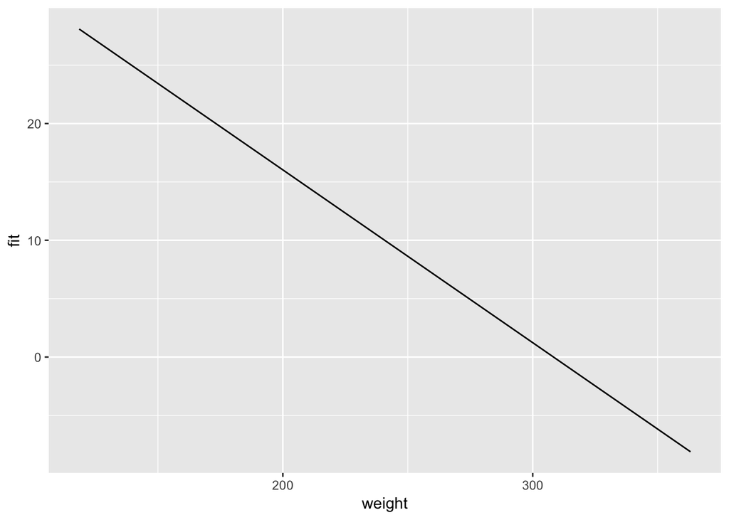

```r
ggplot(n1) +
  geom_line(mapping=aes(x=weight, y=fit))
```

And now we can add the confidence interval:

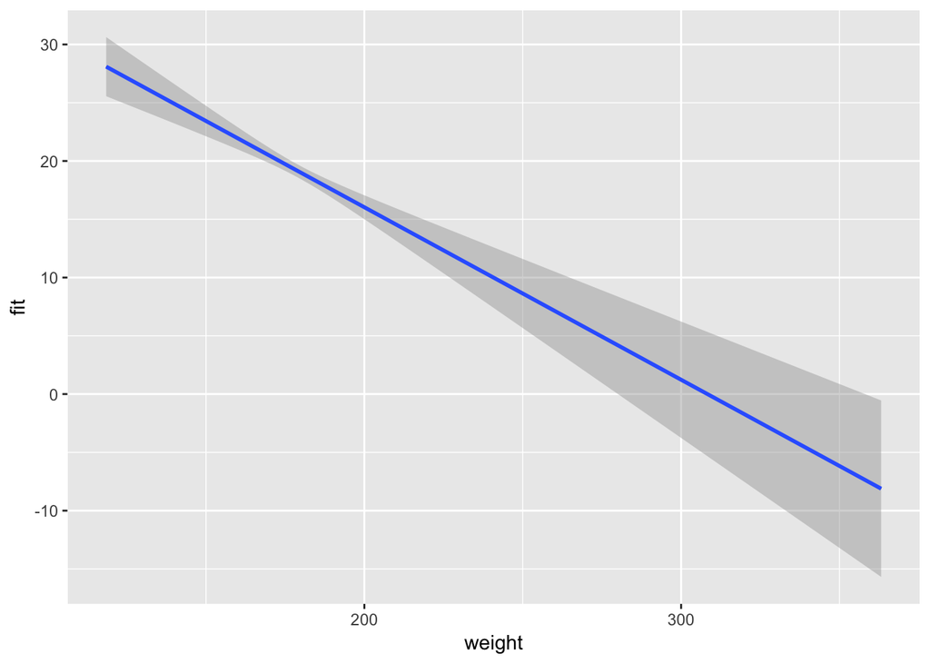

```r
ggplot(n1) +
  geom_line(mapping=aes(x=weight, y=fit)) +
  geom_smooth(mapping=aes(x=weight, y=fit, ymin=lwr, ymax=upr), stat="identity")
```

How does the corresponding graph for `abdomen` predicting `bodyfat` look? We just need to change the data we make and give to `predict`….

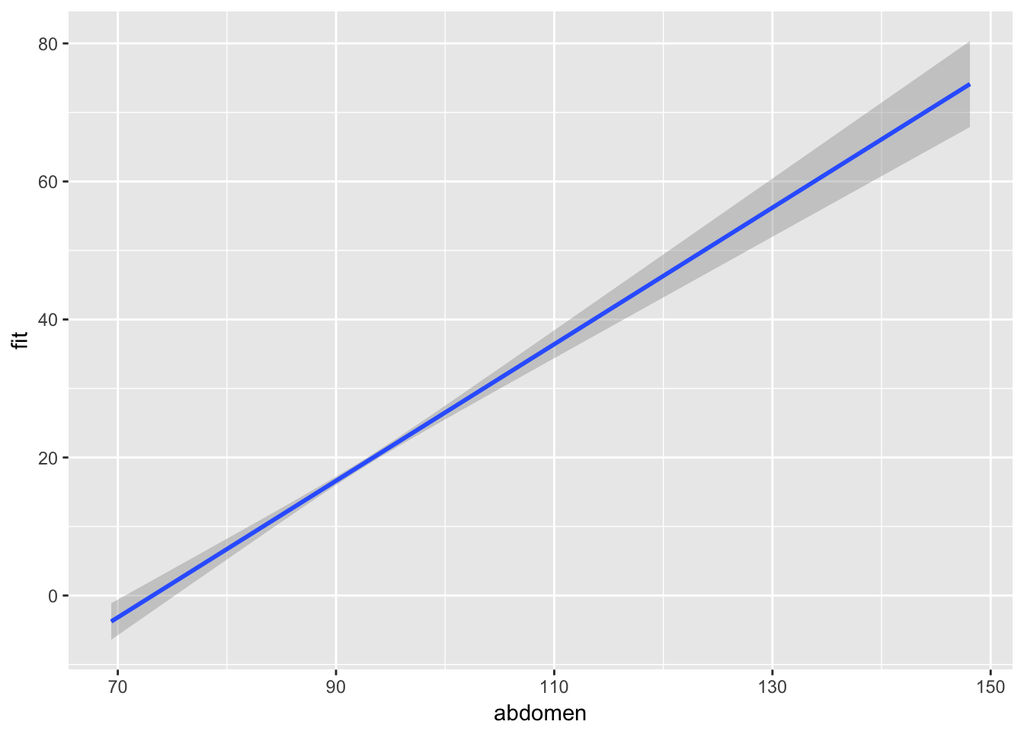

```r
new_data <- expand.grid(weight=mean(dd$weight),
                        abdomen=seq(min(dd$abdomen), max(dd$abdomen), length=100))
p1 <- predict(m1, newdata = new_data, interval="confidence")
n1 <- cbind(new_data, p1)
ggplot(n1) +
  geom_line(mapping=aes(x=abdomen, y=fit)) +
  geom_smooth(mapping=aes(x=abdomen, y=fit, ymin=lwr, ymax=upr), stat="identity")
```

Here we see the predicted value going from 0 to nearly 80. Whereas for `weight` the range of predicted values was lower.

## Reporting results

One option for reporting the findings is to give a table of the coefficients and either confidence intervals or standard errors. Confidence intervals are often considered preferable.

And to plot the two graphs that show the fitted model. There are other graphs one could make, but lets not go there now.

What would we write? Perhaps something like:

In the Methods section: Multiple linear regression with body fat as the response variable and weight and abdomen as two continuous explanatory variables was used. The data met the assumptions of linear regression.

In the Results section: Abdomen measurement was strongly and positively related with the body fat measurement; weight was negatively related with body fat (table 1 contains effect sizes and confidence intervals). Weight and abdoment together explained about 72% of the variation in body fat.

In the Conclusions: Abdomen and weight measurements, which can easily and quickly be made, are promising indicators of body fat. Nevertheless, some development of the predictive model is required, so as to not predict negative values of body fat, and also it should be tested against new data.

## Checking for influence of that outlier

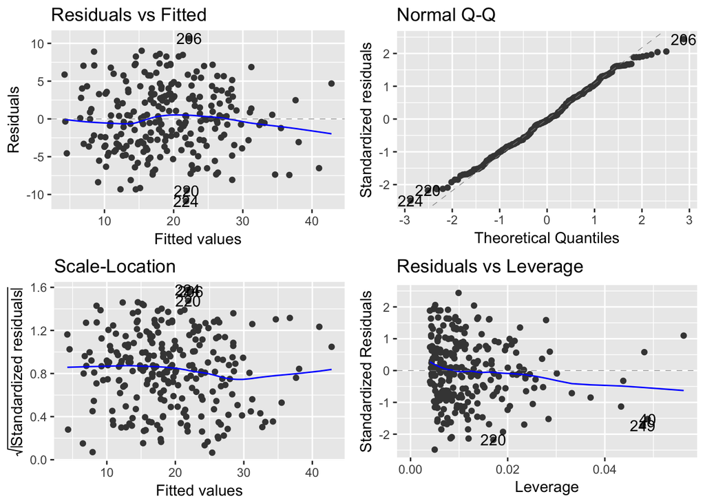

```r
m2 <- lm(bodyfat ~ weight + abdomen, data=slice(dd, -39))
autoplot(m2)
```

```r
coef(m2)
```

```
## (Intercept)      weight     abdomen
## -47.6683311  -0.1328758   0.9793979
```

```r
confint(m2)
```

```
##                   2.5 %       97.5 %
## (Intercept) -52.8569204 -42.47974185
## weight       -0.1745508  -0.09120075
## abdomen       0.8691038   1.08969200
```

```r
coef(m1)
```

```
## (Intercept)      weight     abdomen
## -45.9523732  -0.1480031   0.9895044
```

```r
confint(m1)
```

```
##                   2.5 %      97.5 %
## (Intercept) -51.0830418 -40.8217046
## weight       -0.1889883  -0.1070178
## abdomen       0.8777997   1.1012092
```

Quite robust.